```python
import os
import pandas as pd
import geopandas as gpd
import numpy as np
import matplotlib.pyplot as plt
import feather
import plotly.express as px
import psutil
import libpysal as lp
import rasterio as rio
import contextily as ctx
import shapely.geometry as geom
import mapclassify as mc
%matplotlib inline
```

```python
os.chdir('..')
os.chdir('data')
os.getcwd()
```

```
'C:\\Users\\tpytsui\\Documents\\Surfdrive\\Documents\\_PhD\\_github\\lma_circular-maker-city\\data'
```

# Exploratory Spatial Data Analysis

In this notebook, we will conduct some exploratory spatial data analysis on the afgifte dataset. To simplify the process, the variable we will explore will be the total kg of secondary resources received for each postcode. In this notebook, we will do:

- visualization / mapping (Choropleth - quantiles, equal interval, fisher jenks, boxplot) - this gives us a first visual idea of whether there are patterns in the data.
- global spatial auto-correlation (binary, continuous) - here, we use spatial statistics to understand whether the data is (significantly) spatially clustered.
- local spatial auto-correlation (hotspots, coldspots, spatial outliers) - here, we define the relationship between each postcode and their neighbors, to highlight different types of neighbor relationships that are statistically significant.

After exploring the total kg as a variable, we will go through the same processes for each material type (GNC chapter)

## Preparing dataset

Here we prepare a geodataframe for the ESDA. The dataframe should contain the following columns:

- postcode
- kg
- geometry

```python
%%time
# read postcode 4 map from arcgis
url_pc4 = 'https://opendata.arcgis.com/datasets/4bfb07de89954f5c8404b3fa2845c010_0.geojson' # pc4 areas
nl_pc4 = gpd.read_file(url_pc4)
# get nl province borders
url_nl = 'https://opendata.arcgis.com/datasets/dcfc094c1cd44e109eabc9c48fc9832d_0.geojson'
nl = gpd.read_file(url_nl)

# for postcode centroids, use url = 'https://opendata.arcgis.com/datasets/2bafadb98f2f4f00b9333f68f9ce7154_0.geojson'
# for postcode areas, use url = 'https://opendata.arcgis.com/datasets/6ddc8fa5f502495782cd031da6ad42da_0.geojson'
```

```
Wall time: 2min 16s
```

```python
# read afgifte dataframe
df = feather.read_dataframe('lma/af_2019-2020_matched-codes.feather')
df = df[~df.gnc.isna()] # extract rows with gnc
df.eaPostcode = df.eaPostcode.str[:4]
df = df.groupby(['eaPostcode']).sum().kg.reset_index()
df.rename(columns={'eaPostcode': 'postcode', 'kg': 'kg_received'}, inplace=True)

# geocode
nl_pc4 = nl_pc4[['PC4', 'geometry']]
df = pd.merge(df, nl_pc4, how='right', left_on='postcode', right_on='PC4')
df.drop(labels=['postcode'], axis=1, inplace=True)
df.kg_received = df.kg_received.fillna(0)
df = gpd.GeoDataFrame(df)

# create column with log kg values
def log(x):
    if x > 0:
        return np.log(x)
    else:
        return 0
df['log_kg'] = df.kg_received.map(lambda x: log(x))

df = df.dropna()
df = df.drop(df.index[[3478, 3611]]) # get rid of islands

print('#rows, #columns: {}'.format(df.shape))
df.head()
```

```
#rows, #columns: (4066, 4)
```

|  | kg_received | PC4 | geometry | log_kg |
| --- | --- | --- | --- | --- |
| 0 | 0.0 | 1011 | MULTIPOLYGON (((4.90525 52.37834, 4.90525 52.3... | 0.000000 |
| 1 | 36700.0 | 1012 | MULTIPOLYGON (((4.90326 52.38077, 4.90431 52.3... | 10.510532 |
| 2 | 8465160.0 | 1013 | MULTIPOLYGON (((4.87354 52.40830, 4.87880 52.4... | 15.951469 |
| 3 | 11893780.0 | 1014 | MULTIPOLYGON (((4.87870 52.39549, 4.87868 52.3... | 16.291526 |
| 4 | 0.0 | 1015 | MULTIPOLYGON (((4.88198 52.38408, 4.88253 52.3... | 0.000000 |

## Data at first glance (a-spatial)

Here we take a first glance of the data by creating histograms. The three figures below show the distribution of values (kg received) throughout the dataset.

- **Distribution of whole dataset**: In this figure, we can see that there are many postcodes that receive low amounts of secondary resources (~0-50,000,000kg), while there are a few postcodes that receive high amounts (~700,000,000kg).
- **Distribution of weights < 1 million kg**: In this figure, we can see the trend even more clearly - lots of postcodes receiving low weights, and a few postcodes receiving high weights. This reminds me of the [pareto distribution](https://en.wikipedia.org/wiki/Pareto_distribution), where 80% of of outcomes are due to 20% of causes. In our case, a small number of very big and efficient companies are responsible for receiving most of the s. resources, while a large amount of small companies receive the rest. By looking at the shape of the graph, it is clear that the data doesn't follow a normal distribution (bell curve), but another type of distribution, such as lognormal distribution.
- **Distribution of log(kg) of whole dataset**: In this figure, we try plot the distribution of the natural log of kg received from each postcode. This results in a (somewhat) normal distribution, which a slight skew to the lower values. The fact that the data follows a lognormal distribution is an important caveat, because geographically weighted regression (GWR) models work best when data is normally distributed. Bardia has suggested that we do GWR on the log(kg) instead of kg.

This step doesn't say anything about the spatial relationships - we will explore in the rest of this notebook.

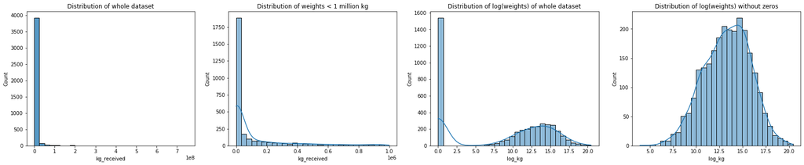

```python
import seaborn as sns
fig, ax = plt.subplots(1, 4, figsize=(8*3.5,5))
sns.histplot(data=df, x="kg_received", bins=30, ax=ax[0])
ax[0].set_title("Distribution of whole dataset")

df_s = df[df.kg_received < 1000000] #le6
sns.histplot(data=df_s, x="kg_received", bins=30, kde=True, ax=ax[1])
ax[1].set_title("Distribution of weights < 1 million kg")

sns.histplot(data=df, x="log_kg", bins=30, kde=True, ax=ax[2])
ax[2].set_title("Distribution of log(weights) of whole dataset")

df_na = df.replace(0, np.NaN)
sns.histplot(data=df_na, x="log_kg", bins=30, kde=True, ax=ax[3])
ax[3].set_title("Distribution of log(weights) without zeros")

plt.show()
```

## Mapping

The four maps below are using the same data - kg of secondary resources received per postcode - but representing it in four different ways.

- **Quantiles**: In quantiles, each postcode is placed in a line, with the postcode with the lowest value (kg) first, and the highest value last. The first 25% of the postcodes are placed into one group (q1), then the next 25% are placed into a second group (q2)...etc. These four groups are then mapped, with the darkest color representing the highest values (kg).
- **Equal interval**: In equal interval, the data is categorized by range, which is ~0-700,000,000kg. Postcodes with weights in the first 25% of the range (~0-175,000,000kg) are placed into one group, then the next 25% are placed in a second group...etc. In this map, you can see that most postcodes belong to the lowest quartile of the dataset, resulting in a mostly light colored map.
- **Fisher jenks**: [The Jenks optimization method](https://en.wikipedia.org/wiki/Jenks_natural_breaks_optimization), also called the Jenks natural breaks classification method, is a data clustering method designed to determine the best arrangement of values into different classes. This is done by seeking to minimize each class's average deviation from the class mean, while maximizing each class's deviation from the means of the other classes. In other words, the method seeks to reduce the variance within classes and maximize the variance between classes.
- **Box plot**: This map is similar to the quartiles map, except it identified outliers in addition to separating the data into four groups.

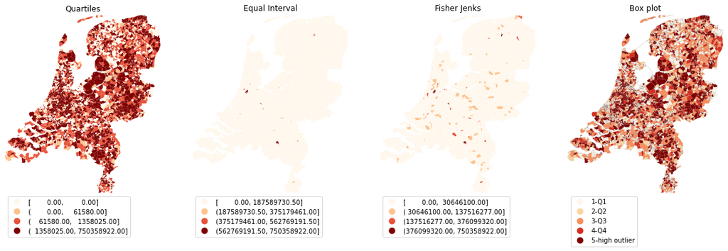

```python
f,ax = plt.subplots(1,4,figsize=(5*4,8), subplot_kw=dict(aspect='equal'))

# quartiles
df.plot(column='kg_received', ax=ax[0],
        scheme="quantiles", cmap='OrRd', k=4, legend=True, legend_kwds={'loc': 'upper left', 'bbox_to_anchor':(0.,0.,0.,0.)})
ax[0].axis(df.total_bounds[np.asarray([0,2,1,3])])
ax[0].set_title("Quartiles")

# equal interval
df.plot(column='kg_received', ax=ax[1],
        scheme='equal_interval', cmap='OrRd', k=4, legend=True, legend_kwds={'loc': 'upper left', 'bbox_to_anchor':(0.,0.,0.,0.)})
ax[1].axis(df.total_bounds[np.asarray([0,2,1,3])])
ax[1].set_title("Equal Interval")

# fisher jenks
df.plot(column='kg_received', ax=ax[2],
       scheme='fisher_jenks', cmap='OrRd', k=4, legend=True, legend_kwds={'loc': 'upper left', 'bbox_to_anchor':(0.,0.,0.,0.)})
ax[2].axis(df.total_bounds[np.asarray([0,2,1,3])])
ax[2].set_title("Fisher Jenks")

# boxplot
import mapclassify as mc
y = df['kg_received']
bp = mc.BoxPlot(y)
labels = ['0-low outlier', '1-Q1', '2-Q2', '3-Q3', '4-Q4', '5-high outlier']
bpl = [labels[b] for b in bp.yb]
df.assign(cl=bpl).plot(column='cl', ax=ax[3], categorical=True, k=4, cmap='OrRd', linewidth=0.1, edgecolor='grey', legend=True,
                       legend_kwds={'loc': 'upper left', 'bbox_to_anchor':(0.,0.,0.,0.)})
ax[3].axis(df.total_bounds[np.asarray([0,2,1,3])])
ax[3].set_title("Box plot")

# turn off axis
ax[0].axis('off')
ax[1].axis('off')
ax[2].axis('off')
ax[3].axis('off')

plt.show()
```

In the figures below, we use the same mapping methods on the natural log of kg received. The equal interval and fisher jenks maps look incredibly different, because the log(kg) values are normally distributed.

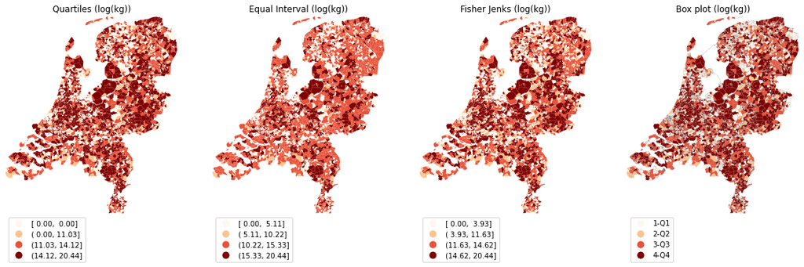

```python
f,ax = plt.subplots(1,4,figsize=(5*4,8), subplot_kw=dict(aspect='equal'))

# quartiles
df.plot(column='log_kg', ax=ax[0],
        scheme="quantiles", cmap='OrRd', k=4, legend=True, legend_kwds={'loc': 'upper left', 'bbox_to_anchor':(0.,0.,0.,0.)})
ax[0].axis(df.total_bounds[np.asarray([0,2,1,3])])
ax[0].set_title("Quartiles (log(kg))")

# equal interval
df.plot(column='log_kg', ax=ax[1],
        scheme='equal_interval', cmap='OrRd', k=4, legend=True, legend_kwds={'loc': 'upper left', 'bbox_to_anchor':(0.,0.,0.,0.)})
ax[1].axis(df.total_bounds[np.asarray([0,2,1,3])])
ax[1].set_title("Equal Interval (log(kg))")

# fisher jenks
df.plot(column='log_kg', ax=ax[2],
       scheme='fisher_jenks', cmap='OrRd', k=4, legend=True, legend_kwds={'loc': 'upper left', 'bbox_to_anchor':(0.,0.,0.,0.)})
ax[2].axis(df.total_bounds[np.asarray([0,2,1,3])])
ax[2].set_title("Fisher Jenks (log(kg))")

# boxplot
import mapclassify as mc
y = df['log_kg']
bp = mc.BoxPlot(y)
labels = ['0-low outlier', '1-Q1', '2-Q2', '3-Q3', '4-Q4', '5-high outlier']
bpl = [labels[b] for b in bp.yb]
df.assign(cl=bpl).plot(column='cl', ax=ax[3], categorical=True, k=4, cmap='OrRd', linewidth=0.1, edgecolor='grey', legend=True,
                       legend_kwds={'loc': 'upper left', 'bbox_to_anchor':(0.,0.,0.,0.)})
ax[3].axis(df.total_bounds[np.asarray([0,2,1,3])])
ax[3].set_title("Box plot (log(kg))")

# turn off axis
ax[0].axis('off')
ax[1].axis('off')
ax[2].axis('off')
ax[3].axis('off')

plt.show()
```

```
postcodes with 0 kg received: 60.9%
```

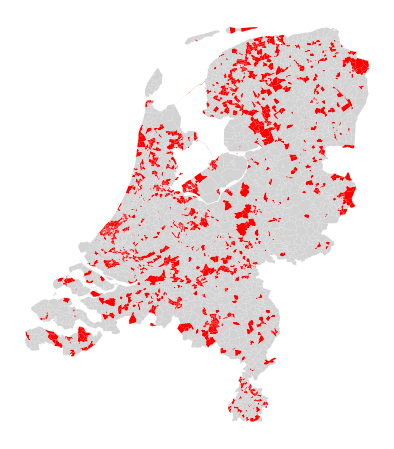

```python
df_0 = df[df.kg_received == 0]
df_n0 = df[df.kg_received != 0]
fig, ax = plt.subplots(1, 1, figsize=(8,8))
df_0.plot(ax=ax, color='red')
df_n0.plot(ax=ax, color='lightgrey')
ax.axis('off')
print('postcodes with 0 kg received: {}%'.format(round(len(df_0) / len(df_n0) * 100, 2)))
plt.show()
```

## Global spatial auto-correlation

Before conducting any spatial analysis, it's important to find out whether the data has any relationship to space - does the data follow any kind of spatial pattern, or are the values just randomly distributed through space? Although we can answer this question from just looking at the map and trying to detect patterns with our eyes, we can also use spatial statistics to get a more accurate understanding of the data.

In order to do this, we look at the dataset and ask the question: 'If we threw values (kg) randomly on the map in simulations, how likely would these simulations resemble our actual data?' or in other words, **'what is the probability that our data (on kg received per pc) is randomly distributed in space?'**

If we find that our data is **not** randomly distributed in space, we can assume that our data is somehow affected by geographical space, and proceed with our spatial analysis. However, if we find that our data **is** randomly distributed in space, there is not point in conducting further spatial analysis. In this case, we will have to further separate the data (by material type, for example) until we get a dataset that isn't randomly distributed in space.

#### Spatial weights, spatial lag

Before we answer the questions above, we first need to find out for each postcode who its neighbors are, and define what we mean by 'neighbors'. For our analysis, we define neighbors as any postcodes that share an edge or a vertex (point). This definition is called a 'queen spatial weight', in reference to the queen chess piece.

Then, we need to describe, for each postcode, the conditions of its neighborhood. We do this by using a process of calculation called spatial lag. Here, for each postcode, we identify its neighbors, then take an average of all their values. This average neighbors' value is then attributed to the postcode. You can see this process in the maps below - the map on the left shows the actual kg received for each post code. The map on the right shows the average kg received of each postcode **by its neighbors** (and not itself).

This allows us to understand whether the postcodes in our data have relationship to its spatial neighbors. For example, do postcodes with high values tend have neighbors with high values as well? Or is it just random, where some high value postcodes have high value neighbors, while others don't?

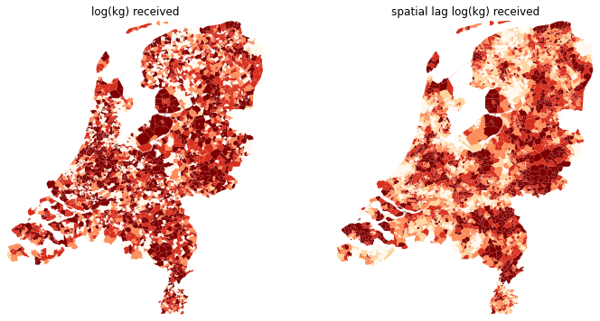

```python
# identify neighbors for each PC
wq =  lp.weights.Queen.from_dataframe(df) # queen spatial weights - for each pc, identify neighbors (other pcs that share a vertex or edge).a
wq.transform = 'r' # weights get row normalized, so when you sum the row, it equals 1.

# describe neighborhood condition for each PC
y = df['log_kg']
ylag = lp.weights.lag_spatial(wq, y) # spatial lag - for each pc, calculate average value of neighbors
df['lag_log_kg'] = ylag

# plot values and spatial lag of values
f,ax = plt.subplots(1,2,figsize=(6*2,6), subplot_kw=dict(aspect='equal'))
df.plot(column='log_kg', ax=ax[0],
        scheme="quantiles",  k=5, cmap='OrRd')
ax[0].axis(df.total_bounds[np.asarray([0,2,1,3])])
ax[0].set_title("log(kg) received")
df.plot(column='lag_log_kg', ax=ax[1],
        scheme='quantiles', cmap='OrRd', k=5)
ax[1].axis(df.total_bounds[np.asarray([0,2,1,3])])
ax[1].set_title("spatial lag log(kg) received")
ax[0].axis('off')
ax[1].axis('off')
plt.show()
```

#### Binary data - explaining the process using a simplified dataset

In order to illustrate this process simply, let's try it out using a simplified version of our data. Here, we separate our data into only two categories - low (values below the median) , and high (values above the median). The map below shows this data.

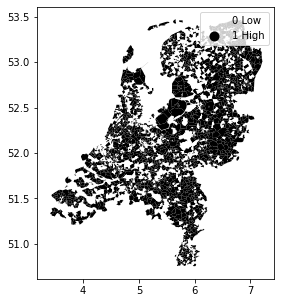

```python
# BINARY CASE
# make binary column (0-Low, 1-High)
y = df['log_kg']
yb = y > y.median() # yb = series that shows whether value is higher or lower than median
labels = ["0 Low", "1 High"]
yb = [labels[i] for i in 1*yb] # False = 0*1 = labels[0] = '0 Low'
df['yb'] = yb

fig = plt.figure(figsize=(5, 5))
ax = plt.gca()
df.plot(column='yb', cmap='binary', legend=True, ax=ax)
plt.show()
```

There are three possible relationships (called joins) between each postcode with each of its neighbors:

- **bb** - or high-high, where the postcode has a high value, and its neighbor has a high value as well.
- **ww** - or low-low, where the postcode has a low value, and its neighbor has a low value as well.
- **bw / wb** - or low-high or high-low, where the postcode has a high value, and its neighborhos has a low value; or vice versa.

The number of joins is summarized in the text below.

```python
import esda
yb = 1 * (y > y.median()) # convert back to binary
# wq =  lp.weights.Queen.from_dataframe(df) # we already have wq object from previous cells
wq.transform = 'b' # what is this?
np.random.seed(12345) # what is this?
jc = esda.join_counts.Join_Counts(yb, wq)

print('''stats on binary data:
no. postcodes: {}
total joins: {}
bb joins: {}
ww joins: {}
bw/wb joins: {}'''.format(len(df), jc.bb + jc.ww + jc.bw, jc.bb, jc.ww, jc.bw))
```

```
stats on binary data:
no. postcodes: 4066
total joins: 11743.0
bb joins: 3955.0
ww joins: 2861.0
bw/wb joins: 4927.0
```

So now that we know the join counts of our actual dataset, we can move on to finding out how similar these numbers are to simulations using random numbers. Using the pySAL esda join counts module, we can 'play creator of the universe' and simulate the same map but with random numbers 999 times. The numbers from these simulations are then compared with our real numbers. If our real numbers are significantly different from our simulations, we can assume that our data is not randomly distributed in space. 'Significantly different' means that there is less than a 5% chance that our data is random **(p-value < 0.05)**.

The process is shown in the histograms below.

- **Simulated vs real bb** - the grey bars show the distribution of the number of bb joins in the 999 simulations, the black line shows the average number of bb joins for the simulations, and the red line shows the number of bb joins in our real data. We can see that our data differs significantly from the simulations, and that the p-value is 0.001, which means that there is only a 0.1% chance that our data is randomly distributed in space.
- **Simulated vs real bw** - the grey bars show the distribution of the number of bw/wb joins in the 999 simulations, the black line shows the average number of bw/wb joins for the simulations, and the red line shows the number of bw/wb joins in our real data. We can see that our data differs significantly from the simulations. However, the p-value here is 1, which doesn't make much sense - I think there's something wrong with my code but I can't figure it out yet.

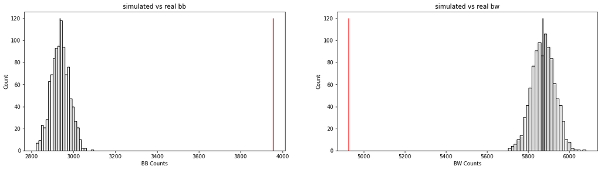

```
no. random simulations: 999
p-value bb: 0.001
p-value bw: 1.0
```

```python
import seaborn as sbn
fig, ax = plt.subplots(1,2, figsize=(10*2, 5))

sbn.histplot(jc.sim_bb, color='lightgrey', ax=ax[0])
ax[0].vlines(jc.bb, 0, 120, color='r')
ax[0].vlines(jc.mean_bb, 0,120)
ax[0].set_xlabel('BB Counts')
ax[0].set_title('simulated vs real bb')

sbn.histplot(jc.sim_bw, color='lightgrey', ax=ax[1])
ax[1].vlines(jc.bw, 0, 120, color='r')
ax[1].vlines(jc.mean_bw, 0,120)
ax[1].set_xlabel('BW Counts')
ax[1].set_title('simulated vs real bw')

plt.show()

print('''no. random simulations: {}
p-value bb: {}
p-value bw: {}'''.format(jc.permutations, jc.p_sim_bb, jc.p_sim_bw))
```

#### Continuous case - a much more accurate look at whether our data is randomly distirbuted in space

Although these p-values in the previous paragraph are impressive, it isn't accurate because we've simplified the data into binary values, losing a lot of information in the process. In order to get a more accurate understanding, we will do the same process on our dataset with continuous values. However, with continuous values, we cannot use join counts to analyse the data, because there are an infinite number of join types between neighbors. So instead, we use another method to measure spatial clustering - Moran's I. (Here's a [helpful video](https://www.youtube.com/watch?v=OJU8GNW9grc&ab_channel=ritvikmath) explaining it)

Moran's I ranges from -1 to 1. 1 means that the data is perfectly clustered; 0 means perfectly random; and -1 means perfectly dispersed.

```python
# CONTINUOUS CASE
wq.transform = 'r'

# calculate moran's I for log(kg)
y = df['log_kg']
np.random.seed(12345)
mi = esda.moran.Moran(y, wq)
print('Moran\'s I for log(kg): {}'.format(mi.I))

# calculate moran's I for normal values
y_n = df['kg_received']
mi_n = esda.moran.Moran(y_n, wq)
print('Moran\'s I for kg: {}'.format(mi_n.I))
```

```
Moran's I for log(kg): 0.17276290555676402
Moran's I for kg: 0.01184108237012216
```

The Moran's I for the dataset is 0.17, which seems quite low. However, Moran's I cannot be interpreted at face value, because it is an inferential statistic (at least according to [this website](https://www.statisticshowto.com/morans-i/)). We can only interpret this number by comparing it to the moran's I of random simulations, similar to the previous process with the binary data. In the figure below, the blue curve shows the distribution of Moran's I values in 999 simulations, the black line shows the average Moran's I value of the simulations, and the red line shows the Moran's I of our actual data.

In the figures below, we can see that the log(kg) values have a statistically significant spatial clustering (p-value = 0.001), while the spatial clustering of the normal (kg) values are not statistically significant (p-value = 0.088 > 0.05). This means that it would be worth conducting spatial analysis on the log(kg) values, but not on the normal kg values. We should also explore further the spatial clustering of different material types to see if those are statistically significant as well.

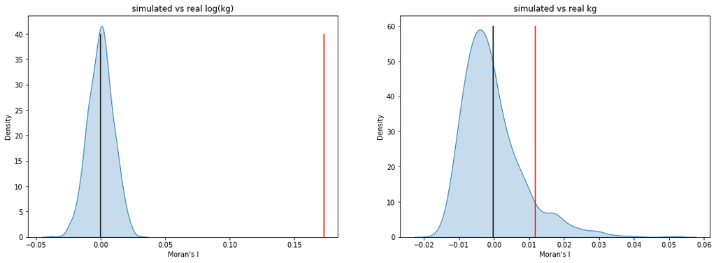

```
p-value for log(kg): 0.001
p-value for kg: 0.088
```

```python
import seaborn as sbn
fig, ax = plt.subplots(1, 2, figsize=(9*2, 6))

sbn.kdeplot(mi.sim, shade=True, ax=ax[0])
ax[0].vlines(mi.I, 0, 40, color='r')
ax[0].vlines(mi.EI, 0, 40)
ax[0].set_xlabel("Moran's I")
ax[0].set_title("simulated vs real log(kg)")

sbn.kdeplot(mi_n.sim, shade=True, ax=ax[1])
ax[1].vlines(mi_n.I, 0, 60, color='r')
ax[1].vlines(mi_n.EI, 0, 60)
ax[1].set_xlabel("Moran's I")
ax[1].set_title("simulated vs real kg")

plt.show()
print('p-value for log(kg): {}'.format(mi.p_sim))
print('p-value for kg: {}'.format(mi_n.p_sim))
```

## Local spatial auto-correlation

The previous analysis explained how spatially clustered the data is as a whole, or its 'global' spatial auto-correlation. Now, we will try to understand the local neighborhood conditions of each postcode, and identifying postcodes that are outliers. To get a better understanding of the data, we created a scatterplot that shows, for each postcode, the relationship for kg received and average kg received by its neighbors. The figure on the right shows a scatterplot of log(kg) values.

The scatterplot can be understood by separating it into four quadrants (the black dotted lines):

- **q1 - hotspots**: postcodes in the **top right** quadrant have high values, and have neighbors that have high values as well.
- **q2 - doughnuts**: postcodes in the **top left** quadrant have low values, but are surrounded by neighbors with high values, like a doughnut - nothing in the middle, good stuff on the outside.
- **q3 - coldspots**: postcodes in the **bottom left** quadrant have low values, and are surrounded by neighbors with low values as well.
- **q4 - diamonds**: postcodes in the **bottom right** quadrant have high values, but are surrounded by neighbors with low values, like a diamond in the rough.

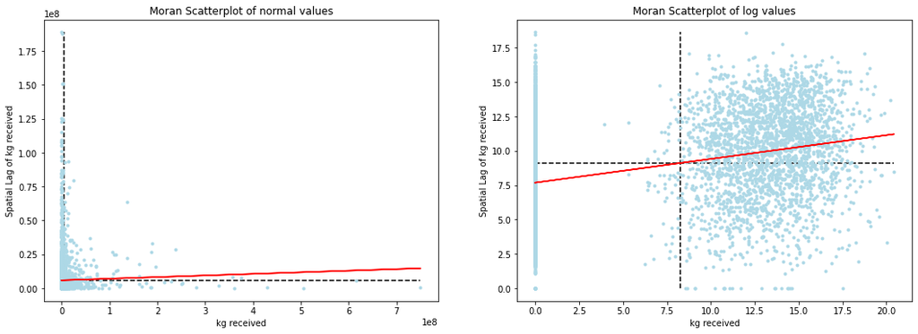

```python
np.random.seed(12345)
# wq =  lp.weights.Queen.from_dataframe(df)
# wq.transform = 'r'

fig, ax = plt.subplots(1, 2, figsize=(9*2, 6))

# PLOT 1: MORAN SCATTERPLOT OF NORMAL VALUES
# create values for moran scatterplot of normal values
kg = df['kg_received']
lag_kg = lp.weights.lag_spatial(wq, df['kg_received']) # average kg_received of neighbors
b, a = np.polyfit(kg, lag_kg, 1) # polynomial of degree 1, aka draw a straight line that best fits the datapoints

# scatterplot of kg versus lagged kg
ax[0].plot(kg, lag_kg, '.', color='lightblue')

# red line of best fit using global I as slope
ax[0].plot(kg, b*kg+a, 'r')
ax[0].set_title('Moran Scatterplot of normal values')
ax[0].set_ylabel('Spatial Lag of kg received')
ax[0].set_xlabel('kg received')

# dashed lines at mean of the kg and lagged kg
ax[0].vlines(kg.mean(), lag_kg.min(), lag_kg.max(), linestyle='--')
ax[0].hlines(lag_kg.mean(), kg.min(), kg.max(), linestyle='--')

# PLOT 2: MORAN SCATTERPLOT OF LOG VALUES
# create values for moran scatterplot of log values
kg_log = df['log_kg']
lag_kg_log = lp.weights.lag_spatial(wq, df['log_kg'])
b_log, a_log = np.polyfit(kg_log, lag_kg_log, 1)

# scatterplot of kg versus lagged kg
ax[1].plot(kg_log, lag_kg_log, '.', color='lightblue')

# red line of best fit using global I as slope
ax[1].plot(kg_log, b_log*kg_log+a_log, 'r')
ax[1].set_title('Moran Scatterplot of log values')
ax[1].set_ylabel('Spatial Lag of kg received')
ax[1].set_xlabel('kg received')

# dashed lines at mean of the kg and lagged kg
ax[1].vlines(kg_log.mean(), lag_kg_log.min(), lag_kg_log.max(), linestyle='--')
ax[1].hlines(lag_kg_log.mean(), kg_log.min(), kg_log.max(), linestyle='--')

plt.show()
```

```python
# calculate local moran
y = df['log_kg']
li = esda.moran.Moran_Local(y, wq) # create local moran's I for each pc
n_sig = (li.p_sim < 0.05).sum() # number of values in li that are smaller than 0.05 (that have a < 5% change of being completely random)

print('''
Number of simulations for local morans I values: {}
p-value of local morans I for each pc: {}
number of pcs with a statistically significant value: {}
'''.format(len(li.sim), li.p_sim, (li.p_sim < 0.05).sum()))
```

```
Number of simulations for local morans I values: 999
p-value of local morans I for each pc: [0.353 0.093 0.497 ... 0.285 0.305 0.18 ]
number of pcs with a statistically significant value: 1003
```

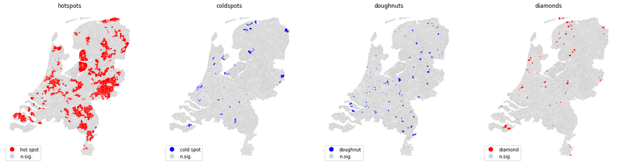

```python
sig = li.p_sim < 0.05 # array showing whether each pc has p-value < 0.05
hotspot = sig * li.q==1 # array showing whether each pc is in q1 AND has p-value < 0.05
coldspot = sig * li.q==3
doughnut = sig * li.q==2
diamond = sig * li.q==4

f,ax = plt.subplots(1,4,figsize=(6*4,8), subplot_kw=dict(aspect='equal'))

spots = ['n.sig.', 'hot spot']
labels = [spots[i] for i in hotspot*1] # why is it hotspot*1 and not just hotspot?
from matplotlib import colors
hmap = colors.ListedColormap(['red', 'lightgrey'])
df.assign(cl=labels).plot(column='cl', categorical=True,
        k=2, cmap=hmap, linewidth=0.1, ax=ax[0], # how does it know what order to put the colors?
        edgecolor='white', legend=True, legend_kwds={'loc': 'lower left', 'bbox_to_anchor':(0.,0.,0.,0.)})
ax[0].set_axis_off()
ax[0].set_title('hotspots')

spots = ['n.sig.', 'cold spot']
labels = [spots[i] for i in coldspot*1]
hmap = colors.ListedColormap(['blue', 'lightgrey'])
df.assign(cl=labels).plot(column='cl', categorical=True,
        k=2, cmap=hmap, linewidth=0.1, ax=ax[1],
        edgecolor='white', legend=True, legend_kwds={'loc': 'lower left', 'bbox_to_anchor':(0.,0.,0.,0.)})
ax[1].set_axis_off()
ax[1].set_title('coldspots')

spots = ['n.sig.', 'doughnut']
labels = [spots[i] for i in doughnut*1]
hmap = colors.ListedColormap(['blue', 'lightgrey'])
df.assign(cl=labels).plot(column='cl', categorical=True, \
        k=2, cmap=hmap, linewidth=0.1, ax=ax[2], \
        edgecolor='white', legend=True, legend_kwds={'loc': 'lower left', 'bbox_to_anchor':(0.,0.,0.,0.)})
ax[2].set_axis_off()
ax[2].set_title('doughnuts')

spots = ['n.sig.', 'diamond']
labels = [spots[i] for i in diamond*1]
hmap = colors.ListedColormap(['red', 'lightgrey'])
df.assign(cl=labels).plot(column='cl', categorical=True, \
        k=2, cmap=hmap, linewidth=0.1, ax=ax[3], \
        edgecolor='white', legend=True, legend_kwds={'loc': 'lower left', 'bbox_to_anchor':(0.,0.,0.,0.)})
ax[3].set_axis_off()
ax[3].set_title('diamonds')

plt.show()
```

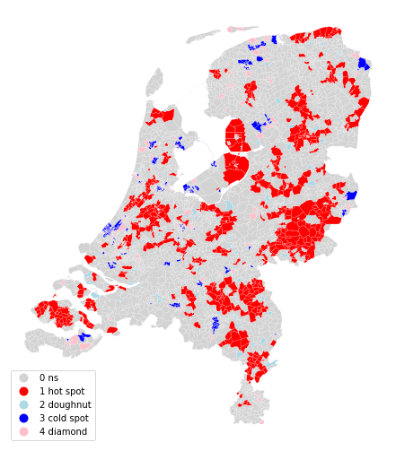

```python
sig = 1 * (li.p_sim < 0.05)
hotspot = 1 * (sig * li.q==1)
coldspot = 3 * (sig * li.q==3)
doughnut = 2 * (sig * li.q==2)
diamond = 4 * (sig * li.q==4)
spots = hotspot + coldspot + doughnut + diamond
spot_labels = [ '0 ns', '1 hot spot', '2 doughnut', '3 cold spot', '4 diamond']
labels = [spot_labels[i] for i in spots]

from matplotlib import colors
hmap = colors.ListedColormap([ 'lightgrey', 'red', 'lightblue', 'blue', 'pink'])
f, ax = plt.subplots(1, figsize=(9, 9))
df.assign(cl=labels).plot(column='cl', categorical=True, \
        k=2, cmap=hmap, linewidth=0.1, ax=ax, \
        edgecolor='white', legend=True, legend_kwds={'loc': 'lower left', 'bbox_to_anchor':(0.,0.,0.,0.)})
ax.set_axis_off()
plt.show()
```